# Project 1

Paul Perez

4/10/2021

# Part A - ATM Forecast

Our goal is for Part A of project 1 to forecast how much cash is taken out of the 4 different ATM machines for May 2010. Given the excel file containing all of our data, there are three columns; `DATE`, `ATM`, and `Cash`. We have to explore the dat and determine the best way to forecast, with little direction.

### Data Collection

As collect the data, we’ll explore the format of the data, types of variables in the set.

```r
atm <- read_excel('ATM624Data.xlsx')
df.atm <- data.frame(atm)
```

### Data Cleanse

```r
head(df.atm)
```

```
##    DATE  ATM Cash
## 1 39934 ATM1   96
## 2 39934 ATM2  107
## 3 39935 ATM1   82
## 4 39935 ATM2   89
## 5 39936 ATM1   85
## 6 39936 ATM2   90
```

```r
dim(df.atm)
```

```
## [1] 1474    3
```

Instantly, we could see that the date format needs to be converted to an actual date format, and the shape of the dataset is 1474, 3 meaning there are 1474 records across 3 columns. We can convert that using the base R cast of `as.Date()` function. This information was source from the below stackoverflow link. [How to convert Excel date format to proper date in R](https://stackoverflow.com/questions/43230470/how-to-convert-excel-date-format-to-proper-date-in-r/62334132)

```r
df.atm$DATE <- as.Date(df.atm$DATE, origin = "1899-12-30")
head(df.atm)
```

```
##         DATE  ATM Cash
## 1 2009-05-01 ATM1   96
## 2 2009-05-01 ATM2  107
## 3 2009-05-02 ATM1   82
## 4 2009-05-02 ATM2   89
## 5 2009-05-03 ATM1   85
## 6 2009-05-03 ATM2   90
```

```r
dim(df.atm)
```

```
## [1] 1474    3
```

Now that we have a dataset with actual dates, we can further evaluate the whole dataset.

```r
summary(df.atm)
```

```
##       DATE                ATM                 Cash
##  Min.   :2009-05-01   Length:1474        Min.   :    0.0
##  1st Qu.:2009-08-01   Class :character   1st Qu.:    0.5
##  Median :2009-11-01   Mode  :character   Median :   73.0
##  Mean   :2009-10-31                      Mean   :  155.6
##  3rd Qu.:2010-02-01                      3rd Qu.:  114.0
##  Max.   :2010-05-14                      Max.   :10919.8
##                                          NA's   :19
```

### Complete Dataframe Analysis

First, we can evaluate the full dataframe, inclusive of all 4 ATM’s data. Afterwards, we can evaluate the subset of the dataframe for each ATM.

For the `DATE` column, we can check the range by looking for the difference in the minimum and maximum dates.

```r
range.full <- max(df.atm$DATE) - min(df.atm$DATE)
range.full
```

```
## Time difference of 378 days
```

Regarding the `ATM` column, a set of categorical variables, we can check to see the number of unique values.

```r
unique(df.atm$ATM)
```

```
## [1] "ATM1" "ATM2" NA     "ATM3" "ATM4"
```

As for the `Cash` column, we can create a histogram to understand the distribution of this numeric variable.

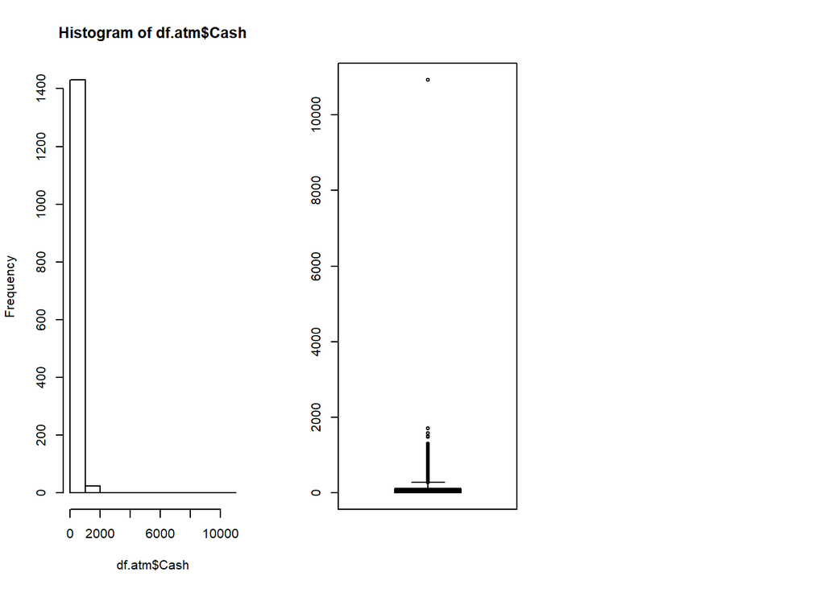

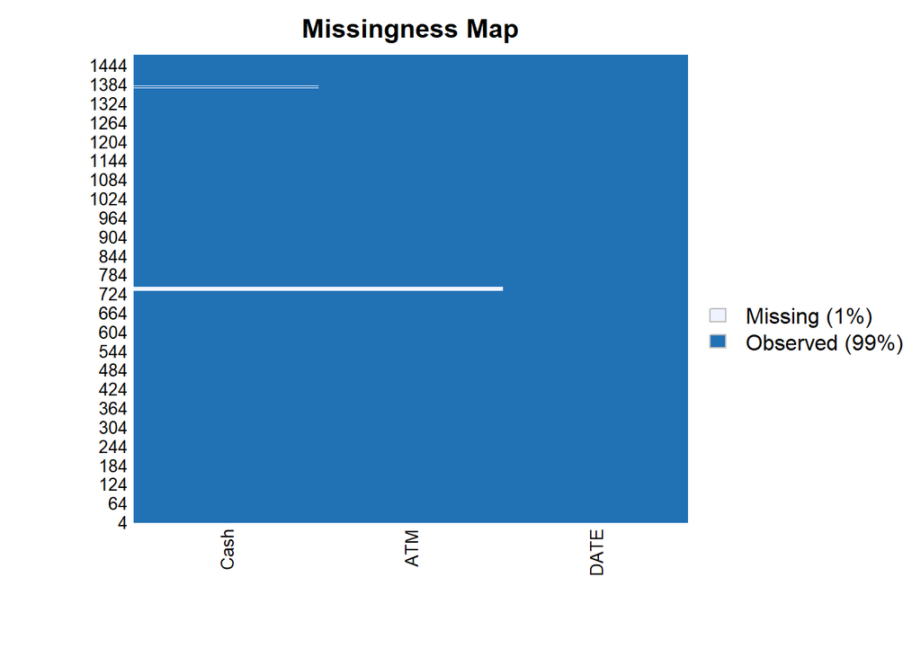

```r
par(mfrow = c(1,3))
hist(df.atm$Cash)
boxplot(df.atm$Cash)
missmap(df.atm)
```

### Create Subsets For Each ATM

After reviewing the full dataset, we could identify positive right skewness along with some outliers. We’ll want to evaluate each of the ATM’s subset of the data to eventually create time series objects out of each. Additionally, we’ll remove the ATM identifier column as it is no longer needed. From each subset, we can use the `missmap` function to see how many observations are missing, and determine whether we should drop them or try to impute the missing values.

```r
df.atm1 <- subset(df.atm, df.atm$ATM == 'ATM1')
df.atm1 <- df.atm1[c('DATE', 'Cash')]
summary(df.atm1)
```

```
##       DATE                 Cash
##  Min.   :2009-05-01   Min.   :  1.00
##  1st Qu.:2009-07-31   1st Qu.: 73.00
##  Median :2009-10-30   Median : 91.00
##  Mean   :2009-10-30   Mean   : 83.89
##  3rd Qu.:2010-01-29   3rd Qu.:108.00
##  Max.   :2010-04-30   Max.   :180.00
##                       NA's   :3
```

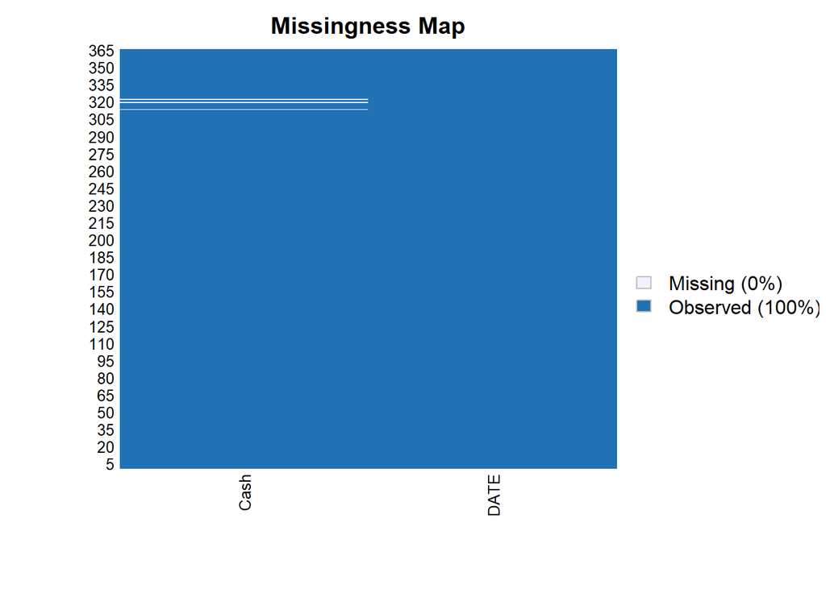

```r
missmap(df.atm1)
```

#### ATM 2

```r
df.atm2 <- subset(df.atm, df.atm$ATM == 'ATM2')
df.atm2 <- df.atm2[c('DATE', 'Cash')]
summary(df.atm2)
```

```
##       DATE                 Cash
##  Min.   :2009-05-01   Min.   :  0.00
##  1st Qu.:2009-07-31   1st Qu.: 25.50
##  Median :2009-10-30   Median : 67.00
##  Mean   :2009-10-30   Mean   : 62.58
##  3rd Qu.:2010-01-29   3rd Qu.: 93.00
##  Max.   :2010-04-30   Max.   :147.00
##                       NA's   :2
```

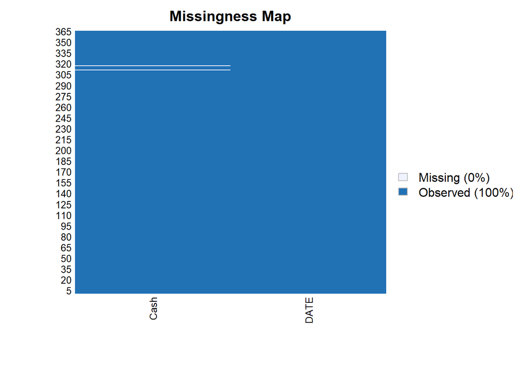

```r
missmap(df.atm2)
```

#### ATM 3

```r
df.atm3 <- subset(df.atm, df.atm$ATM == 'ATM3')
df.atm3 <- df.atm3[c('DATE', 'Cash')]
summary(df.atm3)
```

```
##       DATE                 Cash
##  Min.   :2009-05-01   Min.   : 0.0000
##  1st Qu.:2009-07-31   1st Qu.: 0.0000
##  Median :2009-10-30   Median : 0.0000
##  Mean   :2009-10-30   Mean   : 0.7206
##  3rd Qu.:2010-01-29   3rd Qu.: 0.0000
##  Max.   :2010-04-30   Max.   :96.0000
```

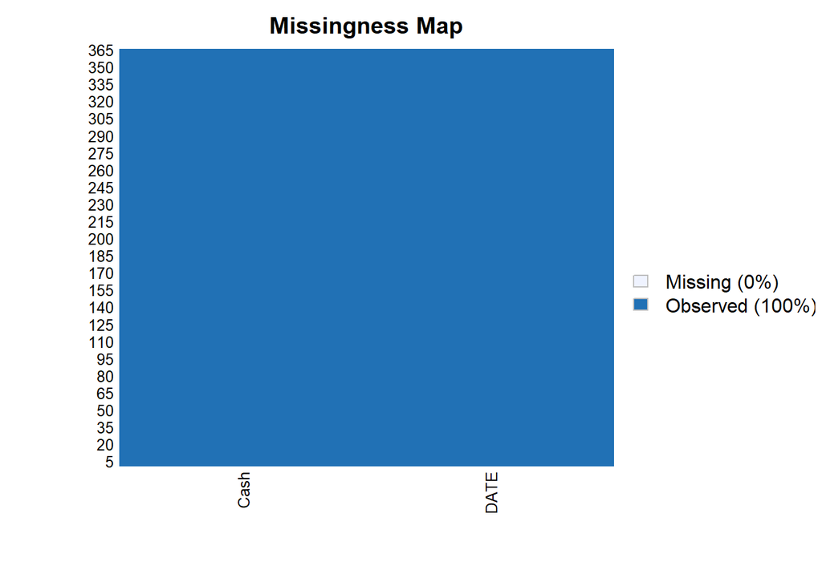

```r
missmap(df.atm3)
```

#### ATM 4

```r
df.atm4 <- subset(df.atm, df.atm$ATM == 'ATM4')
df.atm4 <- df.atm4[c('DATE', 'Cash')]
summary(df.atm4)
```

```
##       DATE                 Cash
##  Min.   :2009-05-01   Min.   :    1.563
##  1st Qu.:2009-07-31   1st Qu.:  124.334
##  Median :2009-10-30   Median :  403.839
##  Mean   :2009-10-30   Mean   :  474.043
##  3rd Qu.:2010-01-29   3rd Qu.:  704.507
##  Max.   :2010-04-30   Max.   :10919.762
```

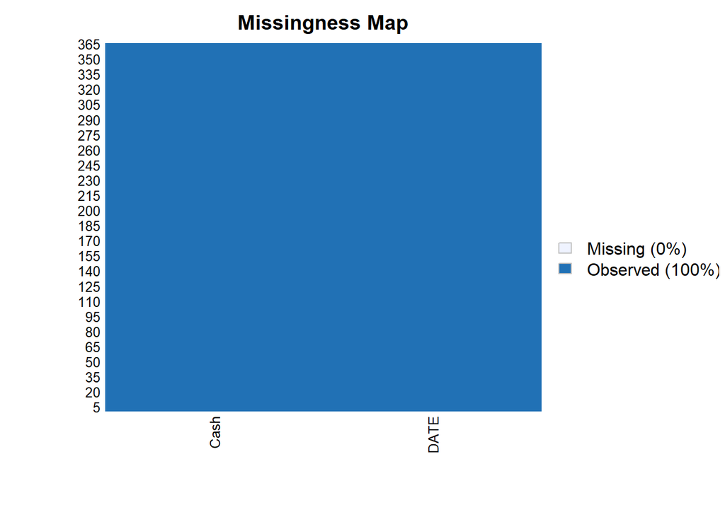

```r
missmap(df.atm4)
```

We can see that ATM’s 1 and 2 were the only ATM’s with missing values, 3 and 2 respectively. With this minimal amount of missing values, we’ll drop them from the two subsets.

```r
df.atm1 <- drop_na(df.atm1)
df.atm2 <- drop_na(df.atm2)
```

## Comparison of Distributions For Each ATM

With the subsets created, missing values removed, we can evaluate each of the respective subset distributions along with the cash withdrawals overtime.

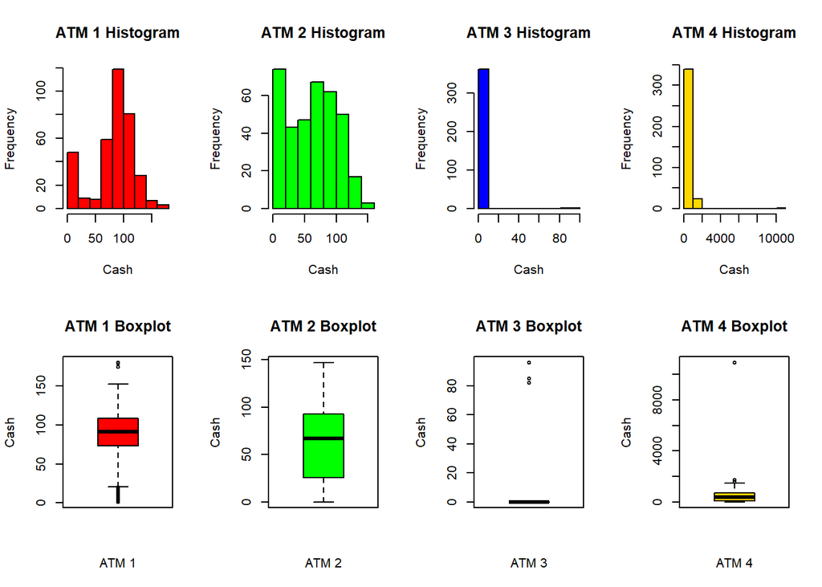

```r
par(mfrow = c(2,4))
hist(df.atm1$Cash, main = 'ATM 1 Histogram', xlab = 'Cash', ylab = 'Frequency', col = 'red')
hist(df.atm2$Cash, main = 'ATM 2 Histogram', xlab = 'Cash', ylab = 'Frequency', col = 'green')
hist(df.atm3$Cash, main = 'ATM 3 Histogram', xlab = 'Cash', ylab = 'Frequency', col = 'blue')
hist(df.atm4$Cash, main = 'ATM 4 Histogram', xlab = 'Cash', ylab = 'Frequency', col = 'gold')
boxplot(df.atm1$Cash, main = 'ATM 1 Boxplot', xlab = 'ATM 1', ylab = 'Cash', col = 'red')
boxplot(df.atm2$Cash, main = 'ATM 2 Boxplot', xlab = 'ATM 2', ylab = 'Cash', col = 'green')
boxplot(df.atm3$Cash, main = 'ATM 3 Boxplot', xlab = 'ATM 3', ylab = 'Cash', col = 'blue')
boxplot(df.atm4$Cash, main = 'ATM 4 Boxplot', xlab = 'ATM 4', ylab = 'Cash', col = 'gold')
```

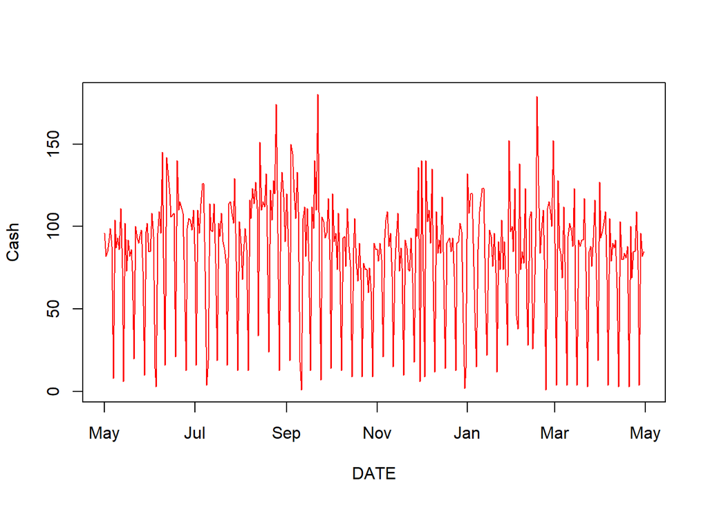

```r
plot(df.atm1, type = 'l', col = 'red')
```

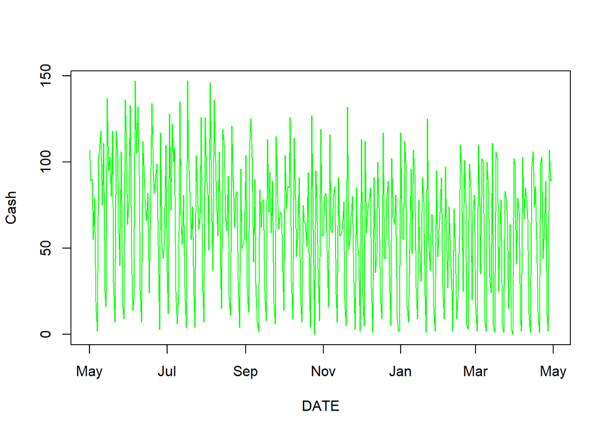

```r
plot(df.atm2, type = 'l', col = 'green')
```

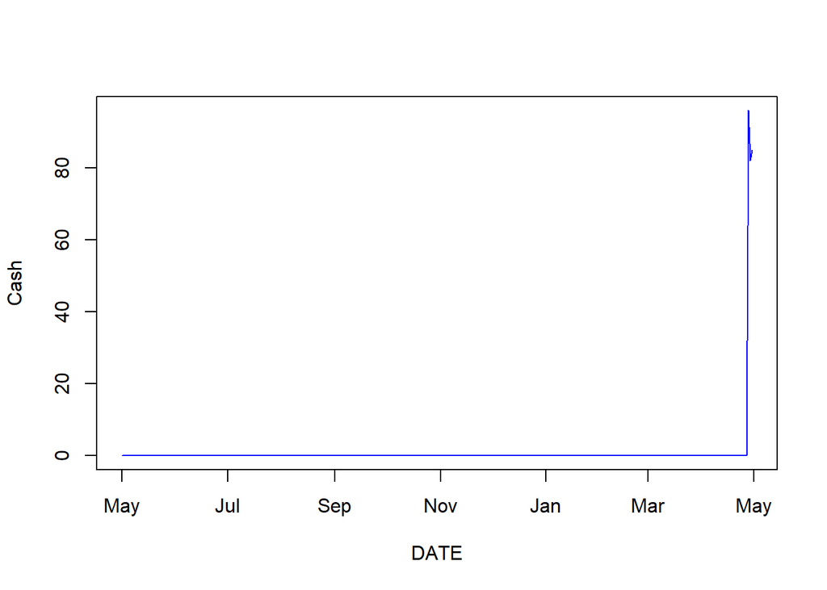

```r
plot(df.atm3, type = 'l', col = 'blue')
```

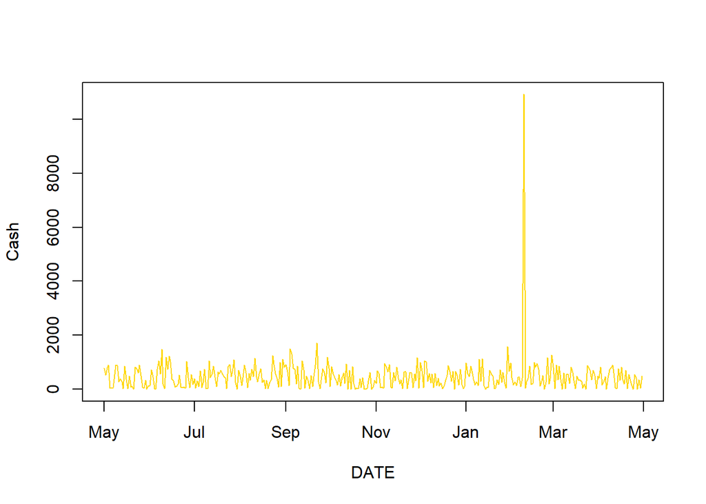

```r
plot(df.atm4, type = 'l', col = 'gold')
```

## Time Series Analysis

To get started, we’ll need to take our subsets and create a time series object for each ATM using the `ts()` function. We’ll specify that the start date for each time series is May 1st, 2009, and the frequency is daily.

```r
ts.atm1 <- ts(df.atm1$Cash, start = c(2009, 5, 1), frequency = 365)
ts.atm2 <- ts(df.atm2$Cash, start = c(2009, 5, 1), frequency = 365)
ts.atm3 <- ts(df.atm3$Cash, start = c(2009, 5, 1), frequency = 365)
ts.atm4 <- ts(df.atm4$Cash, start = c(2009, 5, 1), frequency = 365)
```

### Time Series ATM 1

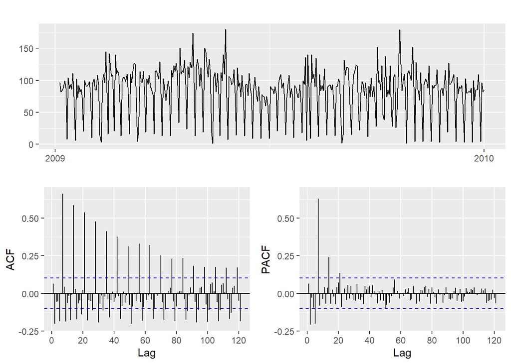

```r
ggtsdisplay(ts.atm1, points = FALSE)
```

Looking at the diagnostics above, we can not identify a clear trend or period of seasonality. The ACF plot shows a correlation especially with the lag of 7. The same can be observed with the PACF plot with the lag of 7.

```r
lam.atm1 <- BoxCox.lambda(ts.atm1)
lam.atm1
```

```
## [1] 1
```

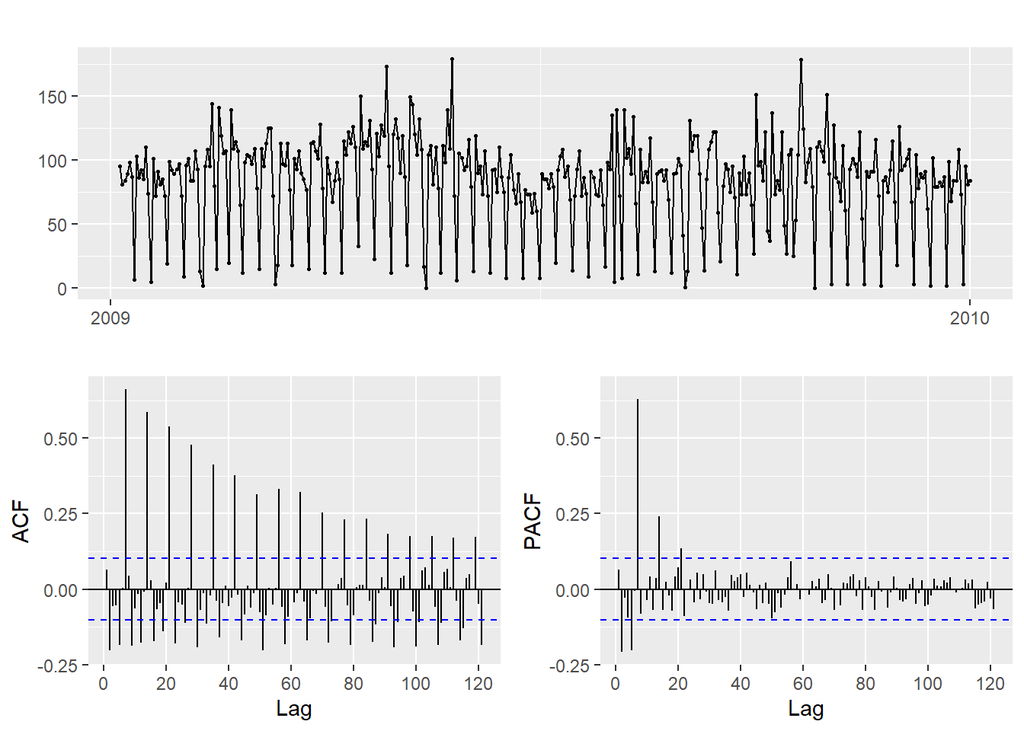

```r
ggtsdisplay(BoxCox(ts.atm1, lam.atm1))
```

We can see that our lambda resulted in 1, not changing our data much if at all.

#### Holt - ATM 1

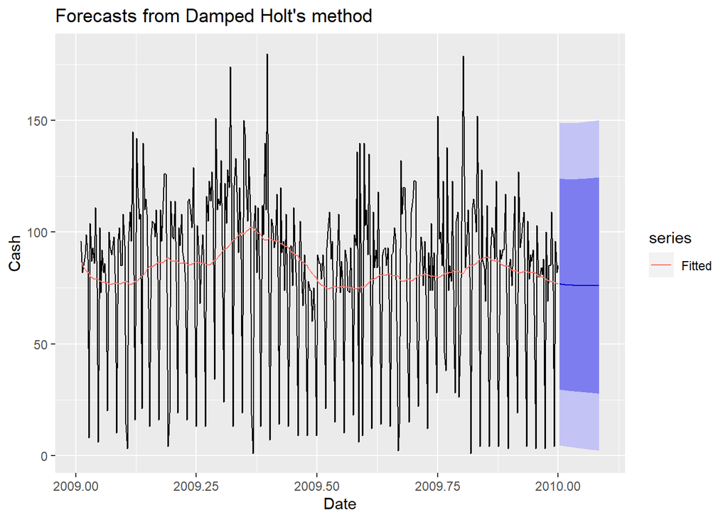

```r
ht.atm1 <- holt(ts.atm1, lambda = lam.atm1, h = 31, damped = TRUE)
autoplot(ht.atm1) +
  autolayer(fitted(ht.atm1), series="Fitted") +
  ylab("Cash") + xlab("Date")
```

```r
accuracy(ht.atm1)
```

```
##                       ME     RMSE      MAE       MPE     MAPE MASE       ACF1
## Training set -0.03437644 36.63236 27.27154 -180.2985 204.0245  NaN 0.05341481
```

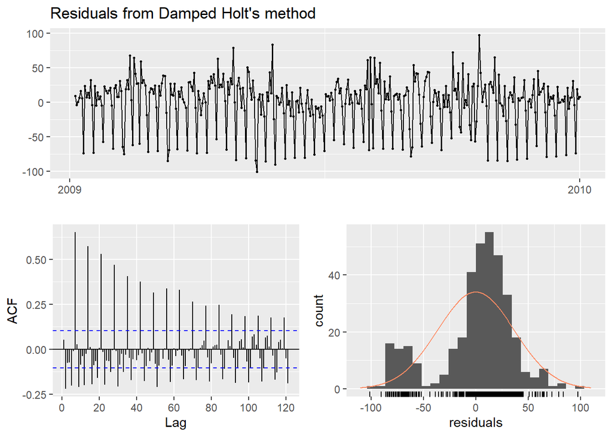

```
##
##  Ljung-Box test
##
## data:  Residuals from Damped Holt's method
## Q* = 1041.9, df = 67, p-value < 2.2e-16
##
## Model df: 5.   Total lags used: 72
```

```r
checkresiduals(ht.atm1)
```

Looking at our residuals, they look very similar to pre-transformation, as well as our ACF plot. We do have a RMSE of 36.63 and a significant p-value less that 0.05 at 2.2e-16.

#### ARIMA - ATM 1

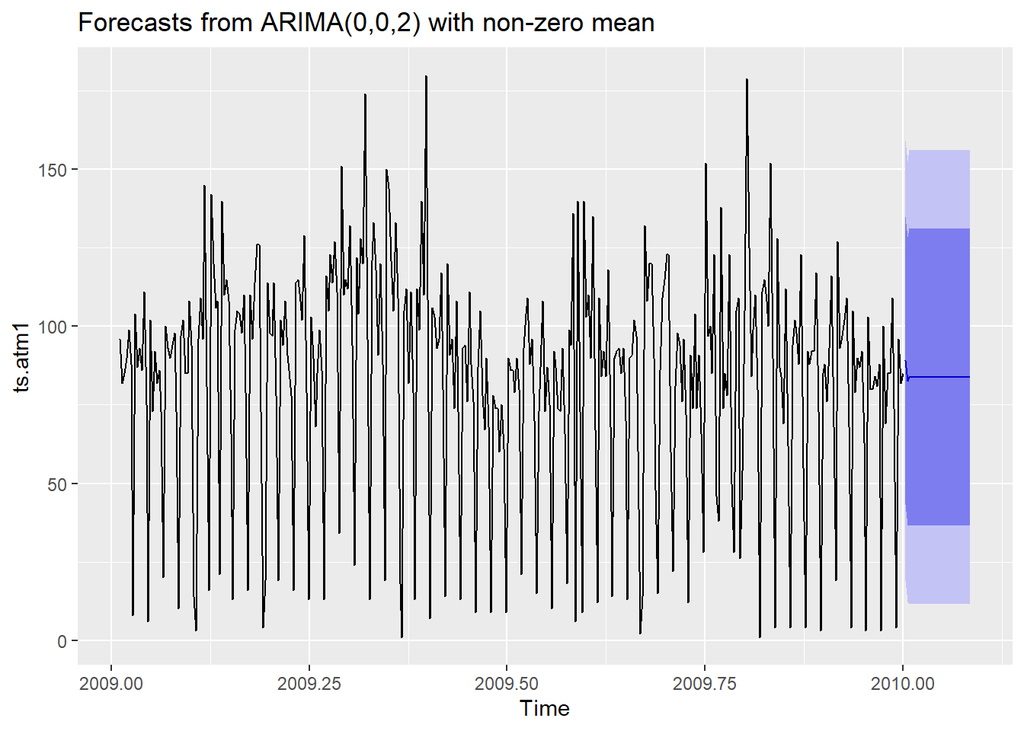

```r
ar.atm1 <- auto.arima(ts.atm1)
autoplot(forecast(ar.atm1, h = 31))
```

```r
accuracy(ar.atm1)
```

```
##                       ME     RMSE      MAE       MPE     MAPE MASE        ACF1
## Training set 0.007055245 35.63488 27.15933 -159.1922 182.3459  NaN 0.008210899
```

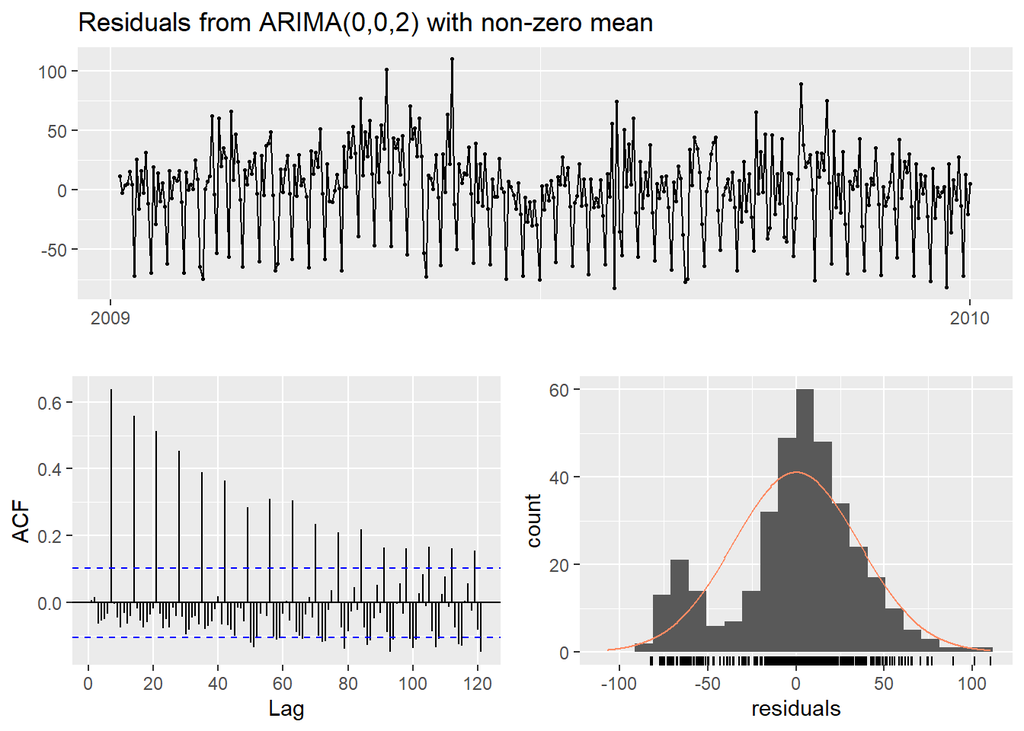

```
##
##  Ljung-Box test
##
## data:  Residuals from ARIMA(0,0,2) with non-zero mean
## Q* = 819.02, df = 69, p-value < 2.2e-16
##
## Model df: 3.   Total lags used: 72
```

```r
checkresiduals(ar.atm1)
```

Looking at our residuals, they look very similar to pre-transformation, as well as our ACF plot. We do have a RMSE of 35.63 and a significant p-value less that 0.05 at 2.2e-16.

#### Forecast Comparison - ATM 1

Now we can compare the two forecasts

```r
comparison <- data.frame(rbind(accuracy(ht.atm1), accuracy(ar.atm1)))
rownames(comparison) <- c('Holt', 'ARIMA')
comparison
```

```
##                 ME     RMSE      MAE       MPE     MAPE MASE        ACF1
## Holt  -0.034376436 36.63236 27.27154 -180.2985 204.0245  NaN 0.053414814
## ARIMA  0.007055245 35.63488 27.15933 -159.1922 182.3459  NaN 0.008210899
```

As we compare the two methods of forecasting, we can see that the ARIMA model, while having the same p-value as the Holt model, has a lower RMSE indicating a better fit. We’ll make sure to use the ARIMA model for our forecast export.

```r
for.atm1 <- data.frame(forecast(ar.atm1, h = 31))
write_csv(remove_rownames(for.atm1), 'Forecast_ATM1.csv')
```

### Time Series ATM 2

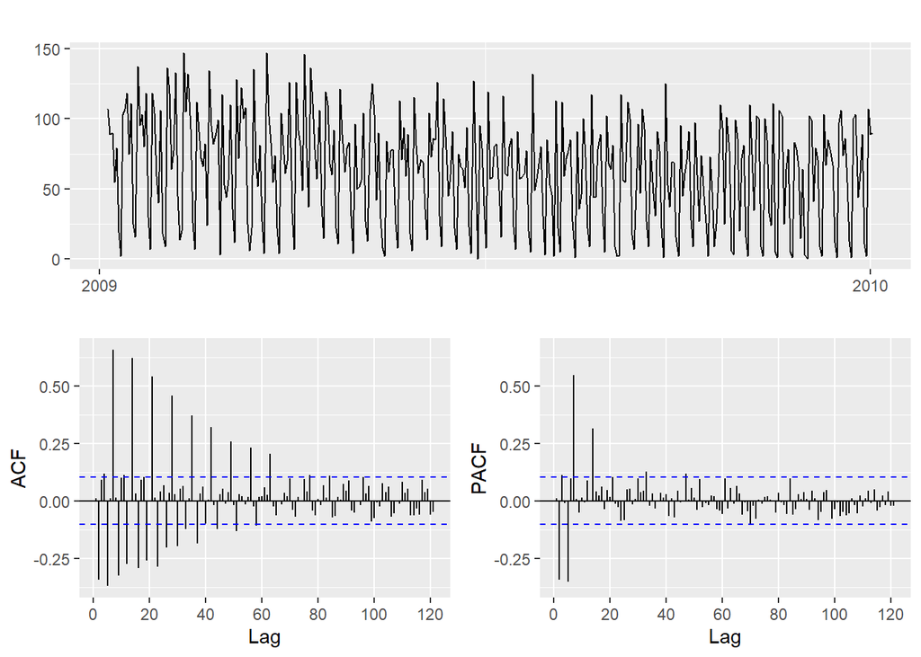

```r
ggtsdisplay(ts.atm2, points = FALSE)
```

Looking at the diagnostics above, we can not identify a clear trend or period of seasonality. The ACF plot shows a correlation especially with the lag of 7. The same can be observed with the PACF plot with the lag of 7 and 14.

```r
lam.atm2 <- BoxCox.lambda(ts.atm2)
lam.atm2
```

```
## [1] 1
```

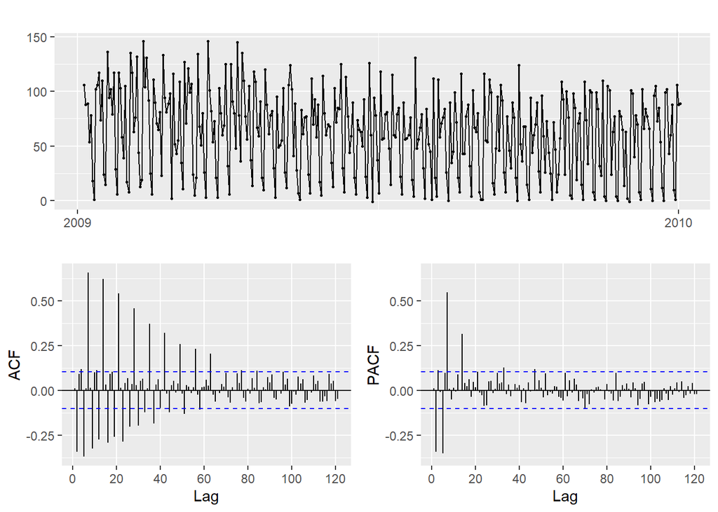

```r
ggtsdisplay(BoxCox(ts.atm2, lam.atm2))
```

We can see that our lambda resulted in 1, not changing our data much if at all.

#### Holt - ATM 2

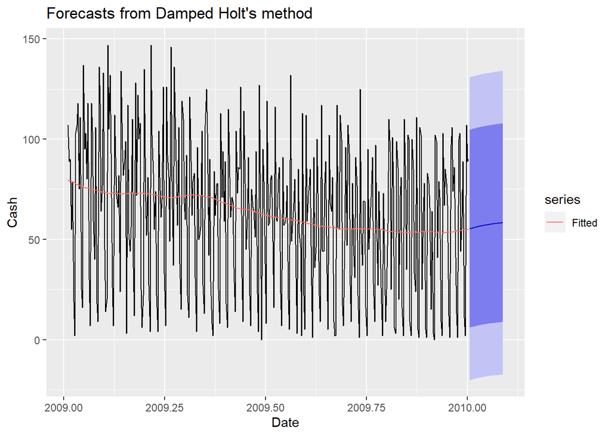

```r
ht.atm2 <- holt(ts.atm2, lambda = lam.atm2, h = 31, damped = TRUE)
autoplot(ht.atm2) +
  autolayer(fitted(ht.atm2), series="Fitted") +
  ylab("Cash") + xlab("Date")
```

```r
accuracy(ht.atm2)
```

```
##                     ME     RMSE      MAE  MPE MAPE MASE        ACF1
## Training set -0.846402 38.25624 32.77158 -Inf  Inf  NaN -0.02067149
```

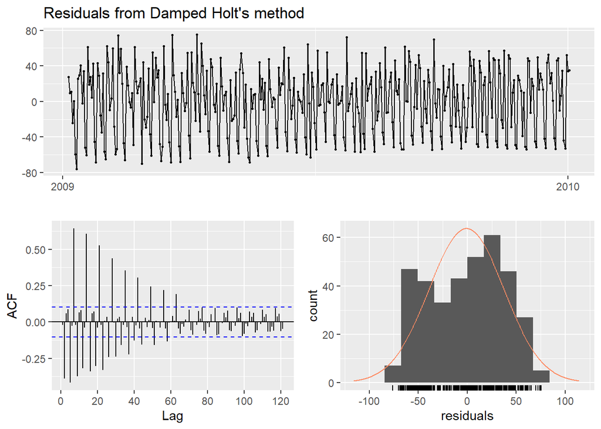

```
##
##  Ljung-Box test
##
## data:  Residuals from Damped Holt's method
## Q* = 1103.7, df = 68, p-value < 2.2e-16
##
## Model df: 5.   Total lags used: 73
```

```r
checkresiduals(ht.atm2)
```

Looking at our residuals, they look very similar to pre-transformation, as well as our ACF plot. We do have a RMSE of 38.25 and a significant p-value less that 0.05 at 2.2e-16.

#### ARIMA - ATM 2

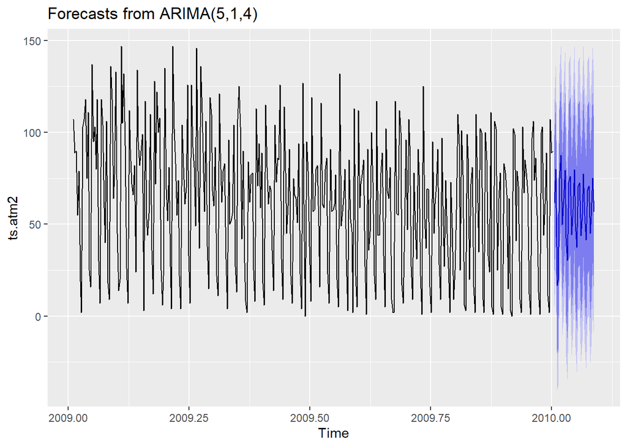

```r
ar.atm2 <- auto.arima(ts.atm2)
autoplot(forecast(ar.atm2, h = 31))
```

```r
accuracy(ar.atm2)
```

```
##                     ME     RMSE      MAE  MPE MAPE MASE        ACF1
## Training set -1.509031 28.27253 22.54609 -Inf  Inf  NaN -0.01925641
```

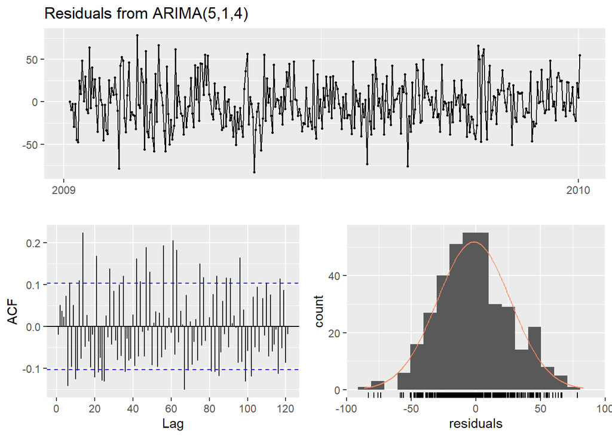

```
##
##  Ljung-Box test
##
## data:  Residuals from ARIMA(5,1,4)
## Q* = 268.48, df = 64, p-value < 2.2e-16
##
## Model df: 9.   Total lags used: 73
```

```r
checkresiduals(ar.atm2)
```

Looking at our residuals, they look very similar to pre-transformation, but the ACF plot has changed to show less of a trend as the lags increase. We see that there is distribution that looks normal with slight skew. Our RMSE is 28.27 and a significant p-value less that 0.05 at 2.2e-16.

#### Forecast Comparison - ATM 2

Now we can compare the two forecasts

```r
comparison <- data.frame(rbind(accuracy(ht.atm2), accuracy(ar.atm2)))
rownames(comparison) <- c('Holt', 'ARIMA')
comparison
```

```
##              ME     RMSE      MAE  MPE MAPE MASE        ACF1
## Holt  -0.846402 38.25624 32.77158 -Inf  Inf  NaN -0.02067149
## ARIMA -1.509031 28.27253 22.54609 -Inf  Inf  NaN -0.01925641
```

As we compare the two methods of forecasting, similar results as our forecast of ATM 1, both models have significant p-values, but the ARIMA model has a lower RMSE of 28.27 compared to 38.25 indicating a better fit. We’ll make sure to use the ARIMA model for our forecast export.

```r
for.atm2 <- data.frame(forecast(ar.atm2, h = 31))
write_csv(remove_rownames(for.atm2), 'Forecast_ATM2.csv')
```

### Time Series ATM 3

As observed in our data preprocessing, there is not enough data to perform a forecast.

### Time Series ATM 4

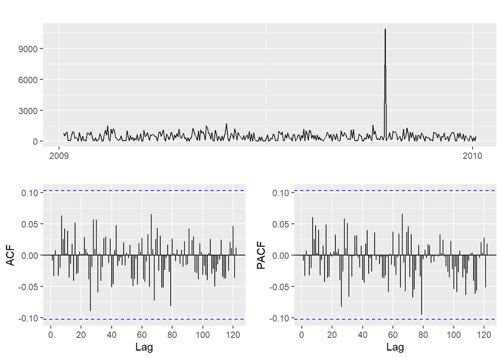

```r
ggtsdisplay(ts.atm4, points = FALSE)
```

Looking at the diagnostics above, we can not identify a clear trend or period of seasonality. There is an outlier that is likely a mistake in the data. The ACF plot shows all lags within the bounds and the same can be said about the PACF plot.

```r
lam.atm4 <- BoxCox.lambda(ts.atm4)
lam.atm4
```

```
## [1] 1
```

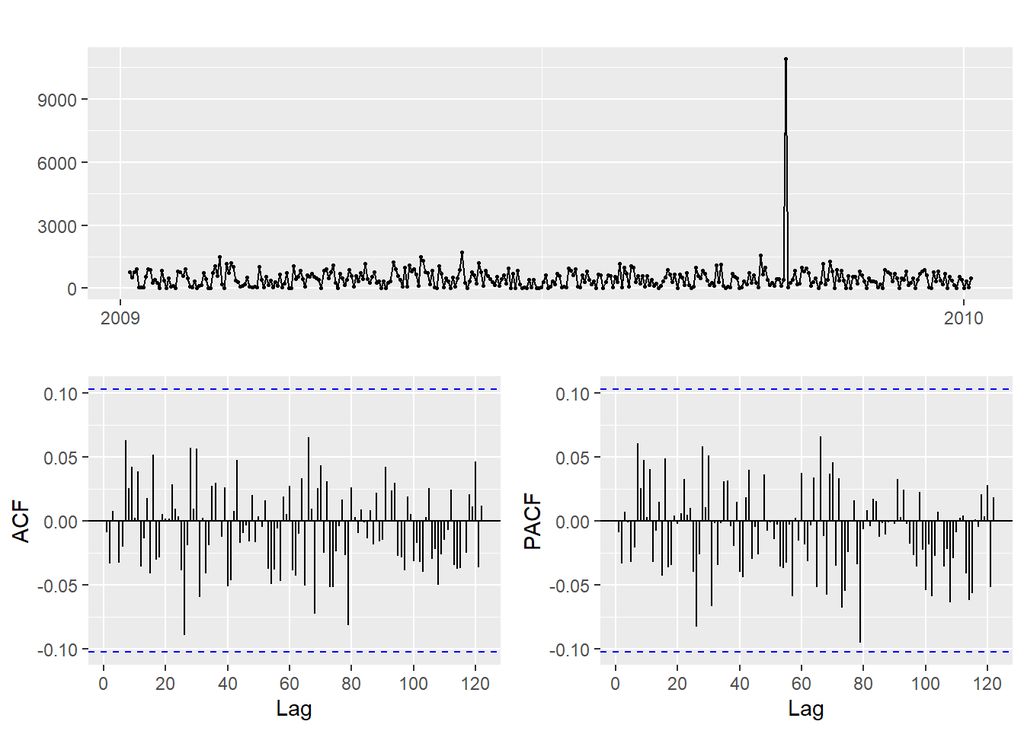

```r
ggtsdisplay(BoxCox(ts.atm4, lam.atm4))
```

We can see that our lambda resulted in 1, not changing our data much if at all.

#### Holt - ATM 4

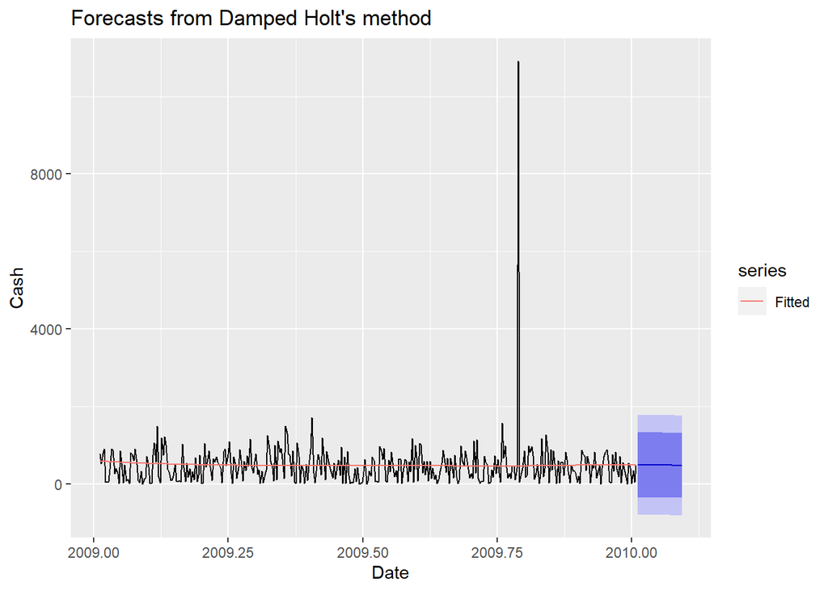

```r
ht.atm4 <- holt(ts.atm4, lambda = lam.atm4, h = 31, damped = TRUE)
autoplot(ht.atm4) +
  autolayer(fitted(ht.atm4), series="Fitted") +
  ylab("Cash") + xlab("Date")
```

```r
accuracy(ht.atm4)
```

```
##                     ME     RMSE      MAE       MPE     MAPE MASE         ACF1
## Training set -13.56529 652.1531 325.9928 -638.8863 667.7268  NaN -0.003297781
```

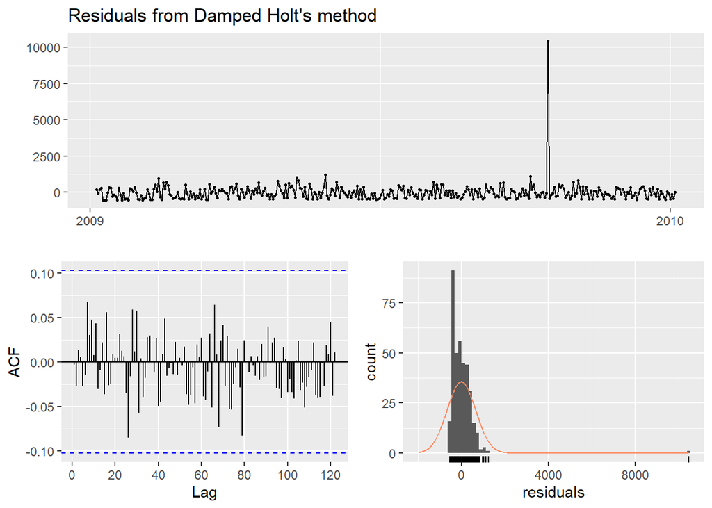

```
##
##  Ljung-Box test
##
## data:  Residuals from Damped Holt's method
## Q* = 34.667, df = 68, p-value = 0.9997
##
## Model df: 5.   Total lags used: 73
```

```r
checkresiduals(ht.atm4)
```

Looking at our residuals, they look very similar to pre-transformation, as well as our ACF plot. We do have a RMSE of 652.15 and a p-value greater than 0.05 at .9997.

#### ARIMA - ATM 4

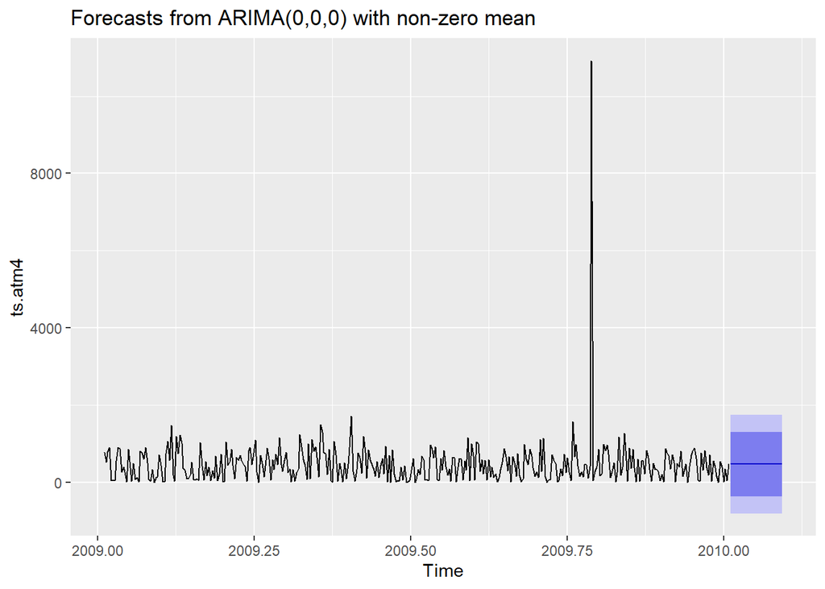

```r
ar.atm4 <- auto.arima(ts.atm4)
autoplot(forecast(ar.atm4, h = 31))
```

```r
accuracy(ar.atm4)
```

```
##                         ME     RMSE      MAE       MPE     MAPE MASE
## Training set -1.514697e-10 650.0437 323.6001 -616.5219 646.8627  NaN
##                      ACF1
## Training set -0.009358419
```

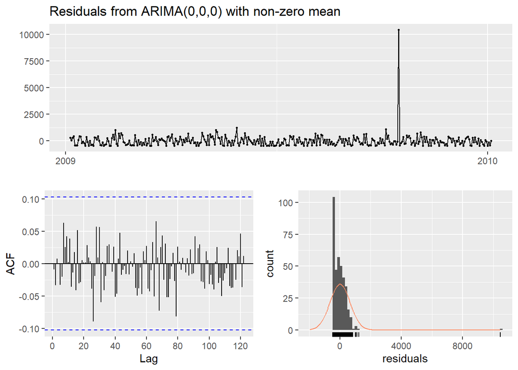

```
##
##  Ljung-Box test
##
## data:  Residuals from ARIMA(0,0,0) with non-zero mean
## Q* = 35.094, df = 72, p-value = 0.9999
##
## Model df: 1.   Total lags used: 73
```

```r
checkresiduals(ar.atm4)
```

#### Forecast Comparison - ATM 4

Now we can compare the two forecasts

```r
comparison <- data.frame(rbind(accuracy(ht.atm4), accuracy(ar.atm4)))
rownames(comparison) <- c('Holt', 'ARIMA')
comparison
```

```
##                  ME     RMSE      MAE       MPE     MAPE MASE         ACF1
## Holt  -1.356529e+01 652.1531 325.9928 -638.8863 667.7268  NaN -0.003297781
## ARIMA -1.514697e-10 650.0437 323.6001 -616.5219 646.8627  NaN -0.009358419
```

As we compare the two methods of forecasting, similar results as our forecast of ATM 1 and ATM 2, but this ATM does not have any significant p-values. The ARIMA model has a lower RMSE of 650.04 compared to 652.15 indicating a better fit. We’ll make sure to use the ARIMA model for our forecast export.

```r
for.atm4 <- data.frame(forecast(ar.atm4, h = 31))
write_csv(remove_rownames(for.atm4), 'Forecast_ATM4.csv')
```

# Part B - Forecasting Power

Given a simple dataset of residential power usage from January, 1998 through Dec3ember, 2013, we’ll need to forecast the residential power for each month of 2014. The variable to forecast is `KWH` which is power consumption in kilowatt hours.

### Data Collection

As collect the data, we’ll explore the format of the data, types of variables in the set.

```r
power <- read_excel('ResidentialCustomerForecastLoad-624.xlsx')
df.power <- data.frame(power)
```

### Data Cleanse

```r
head(df.power)
```

```
##   CaseSequence YYYY.MMM     KWH
## 1          733 1998-Jan 6862583
## 2          734 1998-Feb 5838198
## 3          735 1998-Mar 5420658
## 4          736 1998-Apr 5010364
## 5          737 1998-May 4665377
## 6          738 1998-Jun 6467147
```

```r
dim(df.power)
```

```
## [1] 192   3
```

Seeing that we have a mix of date formats representing the monthly data. We can use the `paste0()` function to add the first day of each month and apply the same date transformation used in Part A of this project.

```r
df.power$YYYY.MMM <- as.Date(paste0(df.power$YYYY.MMM, '-01'), format = '%Y-%b-%d')
head(df.power)
```

```
##   CaseSequence   YYYY.MMM     KWH
## 1          733 1998-01-01 6862583
## 2          734 1998-02-01 5838198
## 3          735 1998-03-01 5420658
## 4          736 1998-04-01 5010364
## 5          737 1998-05-01 4665377
## 6          738 1998-06-01 6467147
```

```r
dim(df.power)
```

```
## [1] 192   3
```

```r
summary(df.power)
```

```
##   CaseSequence      YYYY.MMM               KWH
##  Min.   :733.0   Min.   :1998-01-01   Min.   :  770523
##  1st Qu.:780.8   1st Qu.:2001-12-24   1st Qu.: 5429912
##  Median :828.5   Median :2005-12-16   Median : 6283324
##  Mean   :828.5   Mean   :2005-12-15   Mean   : 6502475
##  3rd Qu.:876.2   3rd Qu.:2009-12-08   3rd Qu.: 7620524
##  Max.   :924.0   Max.   :2013-12-01   Max.   :10655730
##                                       NA's   :1
```

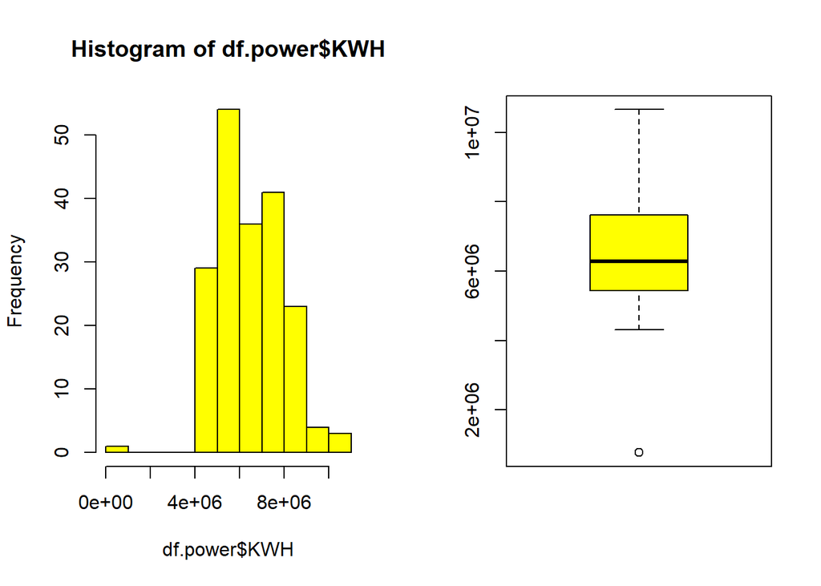

```r
par(mfrow = c(1,2))
hist(df.power$KWH, col = 'yellow')
boxplot(df.power$KWH, col = 'yellow')
```

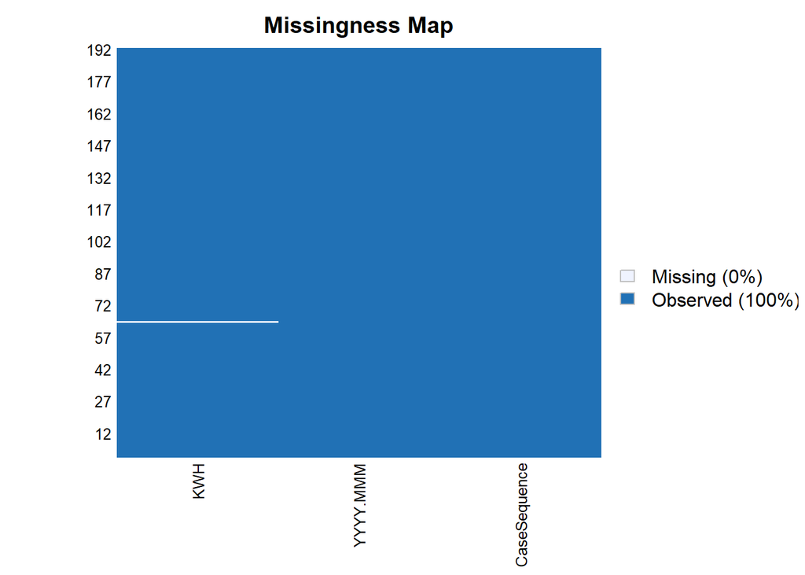

```r
missmap(df.power)
```

Seeing that there is only 1 missing value, we can drop that value, and slice the dataset to only keep the date and kilowatt columns.

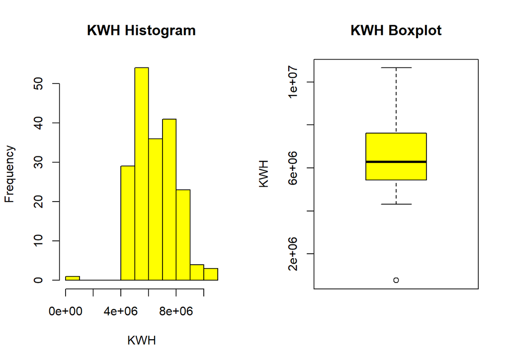

```r
df.power <- drop_na(df.power)
df.power <- df.power[c('YYYY.MMM', 'KWH')]
par(mfrow = c(1,2))
hist(df.power$KWH, main = 'KWH Histogram', xlab = 'KWH', ylab = 'Frequency',col = 'yellow')
boxplot(df.power$KWH, main = 'KWH Boxplot', ylab = 'KWH', col = 'yellow')
```